# Deliverable 2: Cluster Analysis, Factor Analysis, Regression

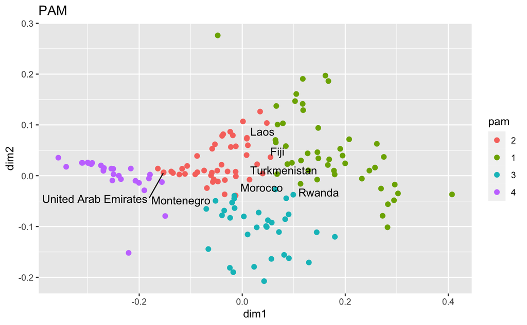

```r
library(ggrepel)
pamPlot + geom_text_repel(aes(label=LABELpam), max.overlaps = Inf)
```

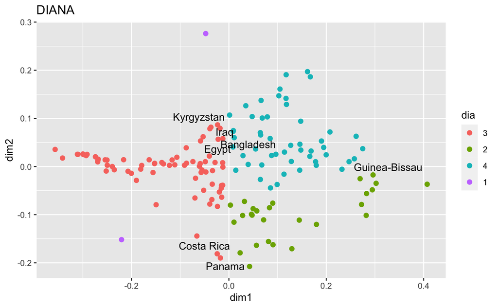

```r
diaPlot + geom_text_repel(aes(label=LABELdia), max.overlaps = Inf)
```

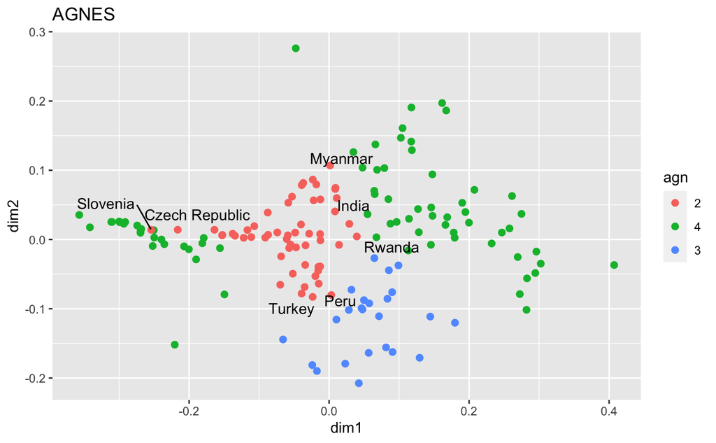

```r
agnPlot + geom_text_repel(aes(label=LABELagn), max.overlaps = Inf)
```

The Dendogram (for hierarchical approaches)

```
`guides(<scale> = FALSE)` is deprecated. Please use `guides(<scale> = "none")` instead.
```

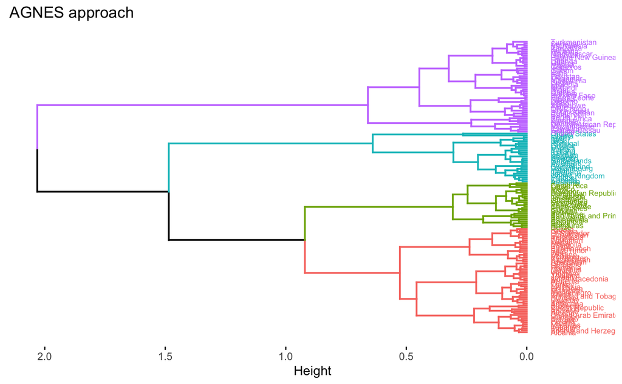

```r
fviz_dend(res.agnes,k=NumberOfClusterDesired, cex = 0.45, horiz = T,main = "AGNES approach")
```

```
`guides(<scale> = FALSE)` is deprecated. Please use `guides(<scale> = "none")` instead.
```

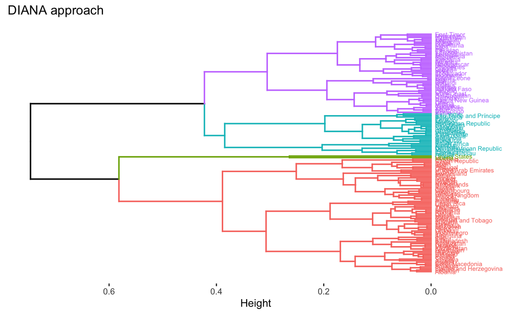

```r
fviz_dend(res.diana,k=NumberOfClusterDesired, cex = 0.45, horiz = T,main = "DIANA approach")
```

Factor Analysis - Latent Concepts

```r
#Creating FA data
#selection
dataForFA = dtcsFinal
names(dataForFA)
```

```
[1] "GiniPercent" "HE2018"      "LE2018"      "pam"         "agn"         "dia"         "dim1"
[8] "dim2"
```

```r
library(lavaan)
```

```r
model = 'healthsys=~ HE2018 + LE2018 + GiniPercent'

fit <- cfa(model, data = dataForFA, std.lv = TRUE)
indexCFA=lavPredict(fit)
```

```r
indexCFA[1:10]
```

```
 [1]  0.47060846  0.47371795 -1.30874907  0.35562305  0.22450684  1.39878912  1.52759672  0.14741568
 [9] -0.07564263  0.34613209
```

```r
#Rescale to 0:10

library(scales)
indexCFANorm=rescale(as.vector(indexCFA),
                     to = c(0, 10))
indexCFANorm[1:10]
```

```
 [1] 6.275947 6.283759 1.805721 5.987073 5.657673 8.607787 8.931387 5.463999 4.903617 5.963229
```

```r
#This is our index

dataForFA$demo_FA=indexCFANorm
```

Comparing new index with original score

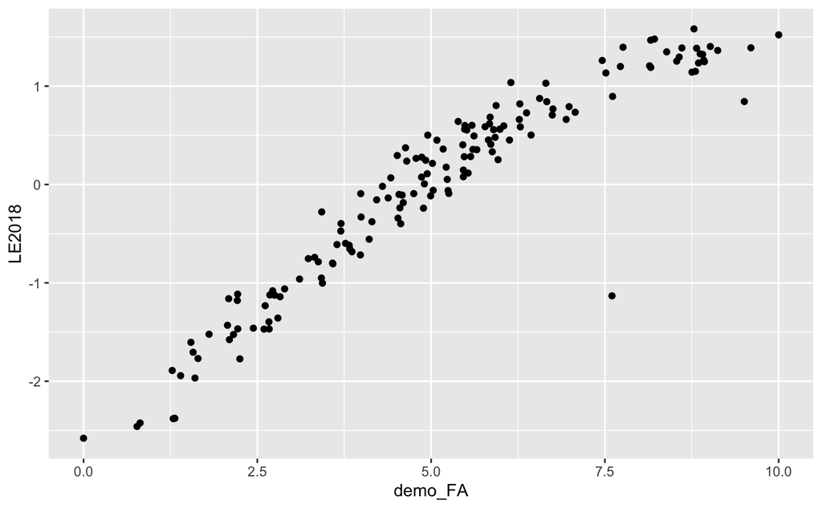

```r
base=ggplot(data=dataForFA,
            aes(x=demo_FA,y=LE2018))
base+geom_point()
```

```r
evalCFA1=parameterEstimates(fit, standardized =TRUE)

evalCFA1[evalCFA1$op=="=~",c('rhs','std.all','pvalue')]
```

|  | rhs | std.all | pvalue |
| --- | --- | --- | --- |
| 1 | HE2018 | 0.695 | 0 |
| 2 | LE2018 | 0.832 | 0 |
| 3 | GiniPercent | -0.500 | 0 |

```r
NA
NA
```

Some coefficients

```r
evalCFA2=as.list(fitMeasures(fit))
```

You want p.value of chi-square greater than .05

```r
evalCFA2[c("chisq", "df", "pvalue")]
```

```
$chisq
[1] 1.358913e-13

$df
[1] 0

$pvalue
[1] NA
```

This is not a greater p-value than .05

You want Tucker-Lewis > .9

```r
evalCFA2$tli # > 0.90
```

```
[1] 1
```

This is does satisfy Tucker-Lewis criteria

You want RMSEA < 0.05:

```r
evalCFA2[c( 'rmsea.ci.lower','rmsea','rmsea.ci.upper')]
```

```
$rmsea.ci.lower
[1] 0

$rmsea
[1] 0

$rmsea.ci.upper
[1] 0
```

Does satisfy RMSEA critera

See how it looks:

```r
#install.packages("semPlot")
library(semPlot)
```

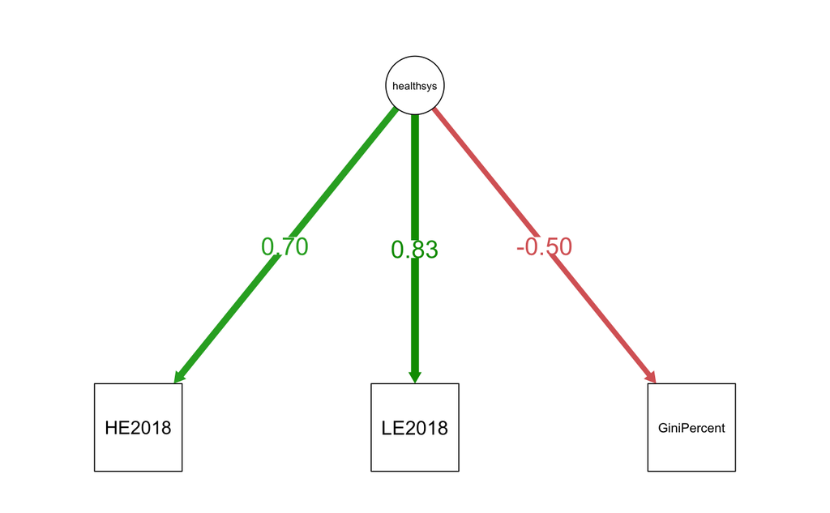

```r
semPaths(fit, what='std', nCharNodes=0, sizeMan=12,
         edge.label.cex=1.5, fade=T,residuals = F)
```

Health expenditure and Life expectancy are positively associated with model, gini percent is negatively associated. Life expectancy is most associated with the health system

REGRESSION

Outcome variable as Life Expectancy, HE2018 and GiniPercent as independent variables?

```r
regData = dtcsFinal
```

- EXPLANATORY APPROACH
1. State hypothesis: Health Expenditure and the Gini Index of a country have an impact on the life expectancy in that country

Prepare your hypothesis:

```r
#FLAG -  Gini is negatively coded (higher gini = higher inequality)
# hypothesis 1: 2018LE increases as gini percent DECREASES (higher equality):
hypo1=formula(LE2018~ GiniPercent)

# hypothesis 2: 2018 LE increases as health expenditure of a country increases

hypo2=formula(LE2018~ HE2018)

#hypothesis 3: 2018 LE increases with higher health expenditure and lower gini score
# -  does this mean needing to make gini negative?
hypo3=formula(LE2018~ HE2018 + GiniPercent)
```

2. Compute regression models

```r
#
# results
gauss1=glm(hypo1,
           data = regData,
           family = 'gaussian')

gauss2=glm(hypo2,
           data = regData,
           family = 'gaussian')


gauss3=glm(hypo3,
           data = regData,
           family = 'gaussian')
```

3. See Results

Hypothesis 1:

```r
summary(gauss1)
```

```
Call:
glm(formula = hypo1, family = "gaussian", data = regData)

Deviance Residuals:
    Min       1Q   Median       3Q      Max
-2.5296  -0.7054   0.2065   0.7032   1.5589

Coefficients:
            Estimate Std. Error t value Pr(>|t|)
(Intercept) -0.02443    0.07543  -0.324    0.746
GiniPercent -0.42332    0.07531  -5.621 8.93e-08 ***
---
Signif. codes:  0 ‘***’ 0.001 ‘**’ 0.01 ‘*’ 0.05 ‘.’ 0.1 ‘ ’ 1

(Dispersion parameter for gaussian family taken to be 0.8704231)

    Null deviance: 158.93  on 152  degrees of freedom
Residual deviance: 131.43  on 151  degrees of freedom
AIC: 416.95

Number of Fisher Scoring iterations: 2
```

– yes, negative coeff on gini percent, p<.05

Hypothesis 2

```r
summary(gauss2)
```

```
Call:
glm(formula = hypo2, family = "gaussian", data = regData)

Deviance Residuals:
    Min       1Q   Median       3Q      Max
-4.2330  -0.3632   0.2508   0.5781   1.1319

Coefficients:
            Estimate Std. Error t value Pr(>|t|)
(Intercept) -0.02489    0.06767  -0.368    0.714
HE2018       0.56127    0.06444   8.710 4.97e-15 ***
---
Signif. codes:  0 ‘***’ 0.001 ‘**’ 0.01 ‘*’ 0.05 ‘.’ 0.1 ‘ ’ 1

(Dispersion parameter for gaussian family taken to be 0.7005489)

    Null deviance: 158.93  on 152  degrees of freedom
Residual deviance: 105.78  on 151  degrees of freedom
AIC: 383.73

Number of Fisher Scoring iterations: 2
```

```r
summary(gauss3)
```

```
Call:
glm(formula = hypo3, family = "gaussian", data = regData)

Deviance Residuals:
    Min       1Q   Median       3Q      Max
-3.8734  -0.3875   0.1500   0.5842   1.4118

Coefficients:
            Estimate Std. Error t value Pr(>|t|)
(Intercept) -0.02272    0.06516  -0.349 0.727837
HE2018       0.47876    0.06618   7.234 2.25e-11 ***
GiniPercent -0.24870    0.06940  -3.584 0.000457 ***
---
Signif. codes:  0 ‘***’ 0.001 ‘**’ 0.01 ‘*’ 0.05 ‘.’ 0.1 ‘ ’ 1

(Dispersion parameter for gaussian family taken to be 0.6496024)

    Null deviance: 158.93  on 152  degrees of freedom
Residual deviance:  97.44  on 150  degrees of freedom
AIC: 373.16

Number of Fisher Scoring iterations: 2
```

Hypothesis as expected, HE 2018 pos coeff & significant, GiniPercent negative coeff and significant

4. Search for a better model

```r
anova(gauss1, gauss2, test="Chisq")
```

```
Analysis of Deviance Table

Model 1: LE2018 ~ GiniPercent
Model 2: LE2018 ~ HE2018
  Resid. Df Resid. Dev Df Deviance Pr(>Chi)
1       151     131.43
2       151     105.78  0   25.651
```

```r
anova(gauss1, gauss3, test="Chisq")
```

```
Analysis of Deviance Table

Model 1: LE2018 ~ GiniPercent
Model 2: LE2018 ~ HE2018 + GiniPercent
  Resid. Df Resid. Dev Df Deviance  Pr(>Chi)
1       151     131.43
2       150      97.44  1   33.994 4.692e-13 ***
---
Signif. codes:  0 ‘***’ 0.001 ‘**’ 0.01 ‘*’ 0.05 ‘.’ 0.1 ‘ ’ 1
```

```r
anova(gauss2, gauss3, test="Chisq")
```

```
Analysis of Deviance Table

Model 1: LE2018 ~ HE2018
Model 2: LE2018 ~ HE2018 + GiniPercent
  Resid. Df Resid. Dev Df Deviance  Pr(>Chi)
1       151     105.78
2       150      97.44  1   8.3425 0.0003388 ***
---
Signif. codes:  0 ‘***’ 0.001 ‘**’ 0.01 ‘*’ 0.05 ‘.’ 0.1 ‘ ’ 1
```

Model for the third hypothesis is chosen (combined HE + gini)

```r
#install.packages("rsq")
library(rsq)
```

```r
rsq(gauss3, adj=T)
```

```
[1] 0.3787309
```

Model 3 has the highest r2 at .379

5. Verify the situation of the chosen model:

5.1 Linearity between dependent variable and predictors is assumed, then these dots should follow a linear and horizontal trend

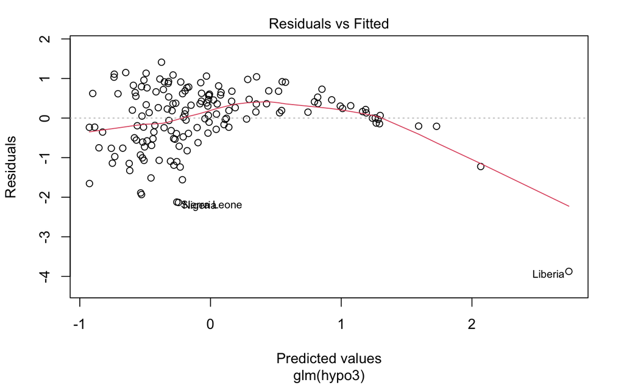

```r
plot(gauss3,1)
```

Linear relationship doesn’t hold

5.2 Normality of residuals is assumed Visual exploration

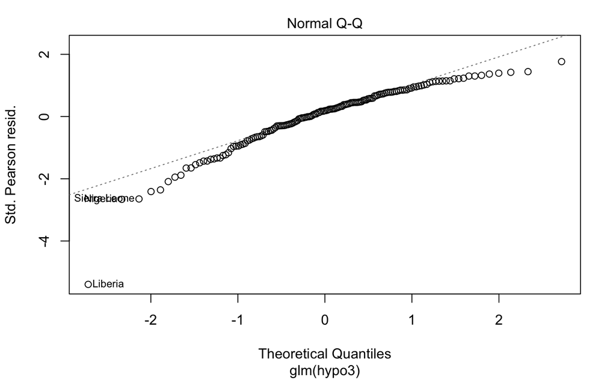

```r
plot(gauss3,2)
```

Mathematical exploration

```r
# The data is normal if the p-value is above 0.05
shapiro.test(gauss3$residuals)
```

```
    Shapiro-Wilk normality test

data:  gauss3$residuals
W = 0.92613, p-value = 4.317e-07
```

so, data is not normally distributed

5.3. Homoscedasticity is assumed, so you need to check if residuals are spread equally along the ranges of predictors:

Visual exploration

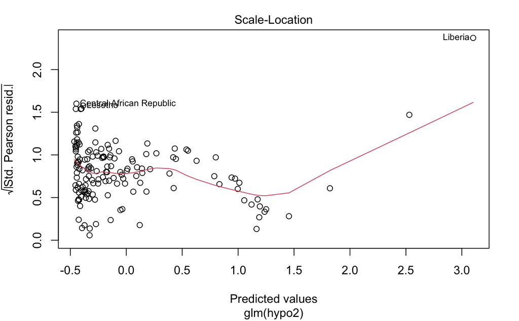

```r
plot(gauss2, 3)
```

Mathematical exploration

```r
#install.packages("lmtest")
library(lmtest)
```

```r
#pvalue<0.05 you cannot assume Homoscedasticity
bptest(gauss3)
```

```
    studentized Breusch-Pagan test

data:  gauss3
BP = 17.152, df = 2, p-value = 0.0001886
```

Cannot assume homoskedacity; p<.05

5.4. We assume that there is no colinearity, that is, that the predictors are not correlated.

```r
library(car)
```

```r
vif(gauss3)
```

```
     HE2018 GiniPercent
   1.137649    1.137649
```

yes, lower than 5 - collinearity is not a problem

5.5. Analize the effect of atypical values. Determine if outliers (points that are far from the rest, but still in the trend) or high-leverage points (far from the trend but close to the rest) are influential:

Visual exploration

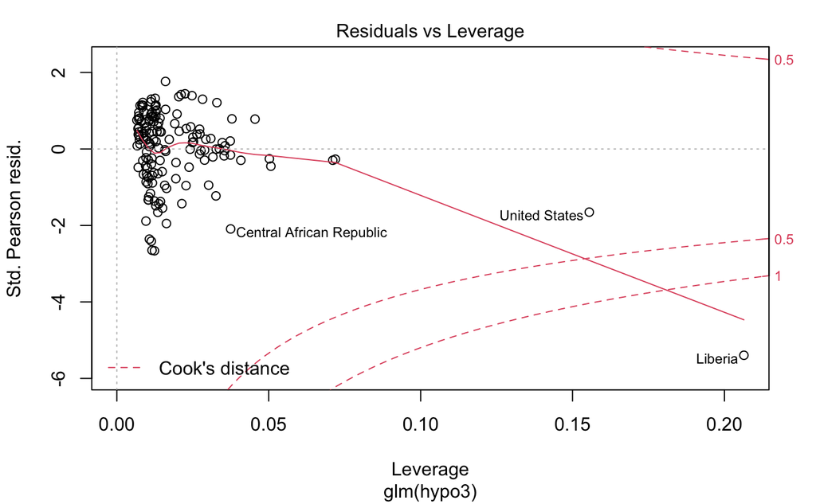

```r
plot(gauss3,5)
```

??What does this mean

Querying

```r
gaussInf=as.data.frame(influence.measures(gauss3)$is.inf)
gaussInf[gaussInf$cook.d,]
```

|  | dfb.1_ | dfb.HE20 | dfb.GnPr | dffit | cov.r | cook.d | hat |
| --- | --- | --- | --- | --- | --- | --- | --- |
| Liberia | FALSE | TRUE | FALSE | TRUE | TRUE | TRUE | TRUE |

6. Finally, a nice summary plot of your work:

```r
#install.packages("sjPlot")
library(sjPlot)
```

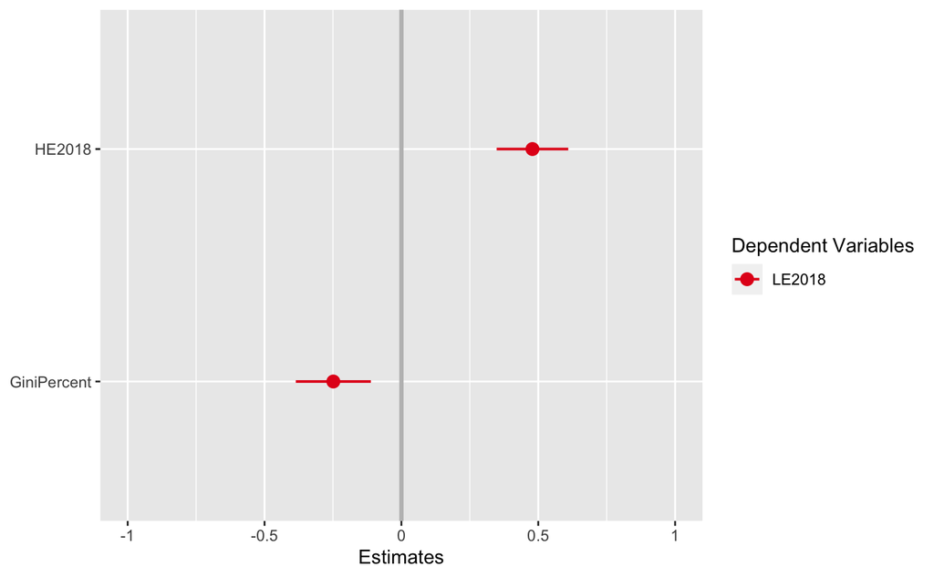

```r
plot_models(gauss3,vline.color="grey")
```

PREDICTIVE APPROACH 1. Split the data set

```r
#install.packages("caret")
library(caret)
```

```r
set.seed(123)

selection = createDataPartition(regData$LE2018,
                                p = 0.75,
                                list = FALSE)
#
trainGauss = regData[ selection, ]
#
testGauss  = regData[-selection, ]
```

```r
ctrl = trainControl(method = 'cv',number = 5)

gauss3CV = train(hypo3,
                 data = trainGauss,
                 method = 'glm',
                 trControl = ctrl)

gauss3CV
```

```
Generalized Linear Model

117 samples
  2 predictor

No pre-processing
Resampling: Cross-Validated (5 fold)
Summary of sample sizes: 94, 93, 94, 93, 94
Resampling results:

  RMSE       Rsquared   MAE
  0.8246734  0.4298554  0.6334076
```

R2 = .4299

3. Evaluate performance

```r
predictedVal<-predict(gauss3CV,testGauss)

postResample(obs = testGauss$LE2018,
             pred=predictedVal)
```

```
     RMSE  Rsquared       MAE
0.7914610 0.5722120 0.6610524
```

R2 now = .572

BINARY OUTCOME Ignore all below here, data is not binary If you have a binary dependent variable (this data is not binary)

```r
#regData$LE2018dico=ifelse(regData$LE2018>median(regData$LE2018,
#                                       na.rm = T),
#                     1,0)
```

*EXPLANATORY APPROACH – IGNORE, data is not binary. Just including for practice 1. State hypothesis

```r
hypoDico1=formula(LE2018dico~ GiniPercent)
hypoDico2=formula(LE2018dico~ HE2018 + GiniPercent)
```

2. Reformat

```r
demoidh$LE2018dico=factor(regData$LE2018dico)
```

Compute regression models

```r
Log1=glm(hypoDico1,data = regData,
         family="binomial")

Logi2=glm(hypoDico2, data=regData,
          family="binomial")
```

See Results - First Hypothesis

```r
summary(Logi1)
```

[output not shown]

- Second Hypothesis

```r
summary(Logi2)
```

[output not shown]

Search for a better model:

```r
lrtest(Logi1,Logi2)
```

[output not shown]

Verify situation of a chosen model

9.1 Linearity assumption (Box-Tidwell test)